# Analisis Sales Marketplace Kopi Sachet

# Pendahuluan

Pada riset kali ini dilakukan scraping pengambilan hasil penjualan Produk Kopi Sachet di platform eCommerce Tokopedia dan Shopee untuk eksplorasi Sales performance dari Merk Merk tersebut

## Tujuan

1. Mengetahui Omset penjualan masing2 Merk Kopi beserta Trend penjualan hariannya
2. Eksplorasi hubungan antara variable seller dengan omset penjualan
3. Melihat Top Seller dari masing2 Merk dan eksplorasi variable top seller tersebut

## Cara Pemilihan Produk

Ada 7 Brand Kopi Sachet yang diambil dalam scraping ini:

1. Kopi Luwak White Koffie
2. Torabika
3. Kapal Api **(hanya Tokopedia saja)**
4. Goodday
5. Lokalate
6. Caffino
7. Top Coffee

## Metode

### Pemilihan Produk yang Discrape

Produk discrape dipilih dengan melakukan pencarian dengan keyword dasar masing2 merk untuk meminimalisir typo dan kesalahan penulisan lainnya

Untuk **Tokopedia**, produk disort berdasarkan **ulasan terbanyak**. Sedangkan **Shopee** disort berdasarkan **Produk Terlaris**. Semua Produk yang terlisting diambil dari Halaman Pertama hingga Halaman dimana produk sudah **tidak memiliki rating atau pembeli**

### Data yang diambil

Data yang berhasil discrape adalah sebagai berikut:

1. Nama Produk
2. Nama Seller
3. Harga
4. Jumlah Barang Terjual
5. Jumaah Barang Dilihat
6. (Untuk Toko Top Seller) Lokasi Toko
7. (Untuk Toko Top Seller) Apakah Toko tersebut menjual Barang secara Grosir
8. (Untuk Toko Top Seller) Jenis Toko

### Periode Pengambilan Data

Data secara rutin diambil pada tanggal 7 September hingga 7 Oktober 2020

# Preprocessing

Untuk dapat masuk ke tahap analisa, data hasil scrape dilakukan ‘pembersihan’ untuk dapat dilakukan pengolahan

## Perubahan Angka `Jumlah Barang Terjual`

Selama periode pengambilan, `Jumlah Barang Terjual` berubah apabila adanya transaksi pembelian di listing tersebut. Namun, ada beberapa produk dimana Angka `Jumlah Barang Terjual` ini malah berkurang dari Hari Sebelumnya. Fenomena ini belum diketahui penyebabnya dan harus dikonfirmasi ke pihak **Shopee** / **Tokopedia**.

Agar tidak terjadi Omset Negatif, dalam perhitungannya, apabila Angka `Jumlah Barang Terjual` lebih rendah dari hari sebelumnya, maka di Hari turunnya tersebut, `Jumlah Barang Terjual` akan dikembalikan/disamakan dengan Angka di Hari sebelumnya.

## Perubahan Harga Produk dan Perhitungan Omset

Selama periode pengambilan, harga dari suatu produk bisa naik atau turun.

Perhitungan Omset Harian dilakukan dengan mengalikan harga pada hari ini dengan selisih `Jumlah Barang Terjual` hari ini dan hari sebelumnya.

## Pengisian Data untuk Produk yang gagal diambil

Saat scraping, terjadi kegagalan pengambilan di beberapa produk. Agar data dapat diolah, Data yang gagal diambil pada hari tersebut akan disamakan dengan Data pada hari sebelumnya.

# Catatan

## Catatan 1

Ada error pengambilan data untuk merk **Kapal Api** di **Shopee,** dimana sebagian besar data tidak berhasil diambil (hanya 50 dari kurang lebih 1000 listed produk).

Harap dijadikan catatan bahwa Data Kapal Api di Shopee tidak dapat dijadikan acuan sehingga semua data Kapal Api yang ditampilkan dibawah diasumsikan tanpa Shopee

## Catatan 2

Pada tanggal 8 dan 17 September 2020, terdapat Anomali Sales pada Beberapa Merk dimana Sales dalam 1 hari meningkat Tajam. Fenomena ini tidak diketahui alasannya.

Berikut adalah list Produk Anomali tersebut, dapat dilihat dalam sehari Salesnya mencapai 16rb hingga 65rb item

Merk-merk yang menjadi Perhatian - Kapal Api - Lokalate - Goodday

|  | Marketplace | Merk | seller | nama | waktu.scrape | harga | QTY Sales per Hari |
| --- | --- | --- | --- | --- | --- | --- | --- |
| 1 | Tokopedia | Kapal Api | Duren Jatohan | KOPI KAPAL API SPECIAL MIX 1 RENTENG @10sachet | 2020-09-17 | 10890 | 65307 |
| 2 | Tokopedia | Kapal Api | KevKen Shop | KAPAL API Kopi Spesial Mix 3 in 1 renceng isi 10 sachet bungkus 25 g | 2020-09-17 | 10989 | 22540 |
| 3 | Tokopedia | Lokalate | 3F Retail | BARU!!! W'DANK LOKALATE Kopi Gula Aren | 2020-09-08 | 13701 | 16069 |
| 4 | Tokopedia | Luwak White Coffee | Toko Iwam | Kopi Sachet Luwak White Koffie renceng | 2020-09-08 | 10500 | 7566 |
| 5 | Tokopedia | Good Day | ASA DIAH MART | Good Day Mocacinno 250 Ml isi 24 Pcs | 2020-09-08 | 111000 | 5979 |
| 6 | Tokopedia | Kapal Api | supercemilan | Kapal Api Special Mix Sachet 25 Gram isi 10 Pcs | 2020-09-17 | 10300 | 3005 |
| 7 | Tokopedia | Luwak White Coffee | supercemilan | Kopi Luwak White Koffie isi 10 Sachet | 2020-09-17 | 10000 | 1630 |
| 8 | Tokopedia | Kapal Api | Gerai Cipta Dagang | kopi kapal api spesial mix \| 1 renceng (10 pcs) | 2020-09-08 | 10395 | 1538 |
| 9 | Tokopedia | Torabika | 3F Retail | Torabika Tora Cafe CAPUCCINO - Kopi ala Cafe | 2020-09-08 | 8201 | 1524 |
| 10 | Tokopedia | Kapal Api | Warung Pintar Indonesia | Kapal Api Special Mix Sachet 25 gr | 2020-09-27 | 10652 | 1334 |

[output cut: 50 more lines]

> Untuk menghindari ketimpangan data, outlier / data sales harian diatas 1630 tidak akan dipakai

# Basis Data

## Basis Omset Per Brand

Sebelum kita masuk ke tahap analisis, kita akan melihat terlebih dahulu Basis Data yang akan kita gunakan.

Sejak tanggal 7 September hingga 7 Oktober 2020, **Total Omset dari Kopi Sachet** di kedua Marketplace (**tanpa Kapal Api di Shopee**) adalah sebesar **Rp 1.9141 Miliar**. Yang jika kita lihat berdasarkan Merknya adalah sebagai berikut, (NS dipakai hanya sebagai acuan)

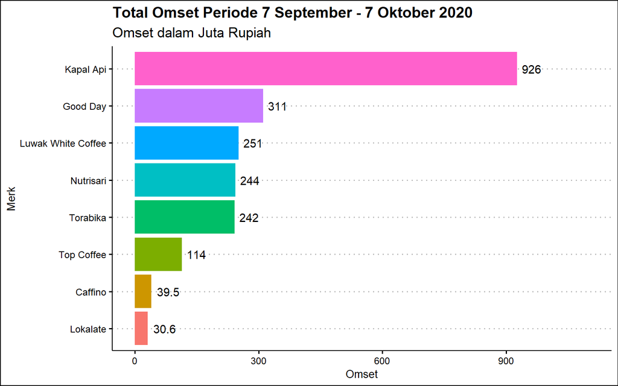

Merk **Kapal Api** sebagai *Market Leader* dari Kopi Sachet memiliki Omset hampir **3x Merk lainnya (belum termasuk Omset Shopee)**

Masuk ke pertanyaan pertama, *Apakah Omset Total ini ada Korelasi dengan Jumlah Penjual atau Item Listednya?*

## Jumlah Seller per Brand

Pertama, dari jumlah sellernya, terdapat sekitar 700-800an seller untuk Top 3 *Market Leader.*

Lokalate memiliki 106 seller yang tersebar di Tokopedia dan Shopee (termasuk Nutrimart). Sebagai acuan, Nutrisari memiliki 515 seller.

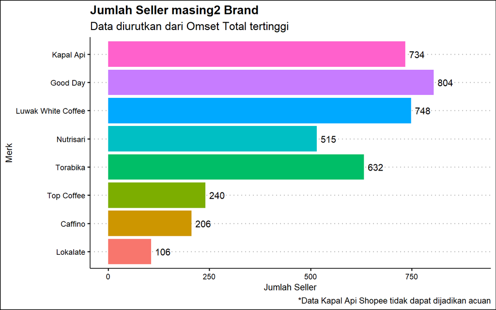

## Jumlah Listed per Brand

Sedangkan dari Listed Produk, , (NS dipakai hanya sebagai acuan)

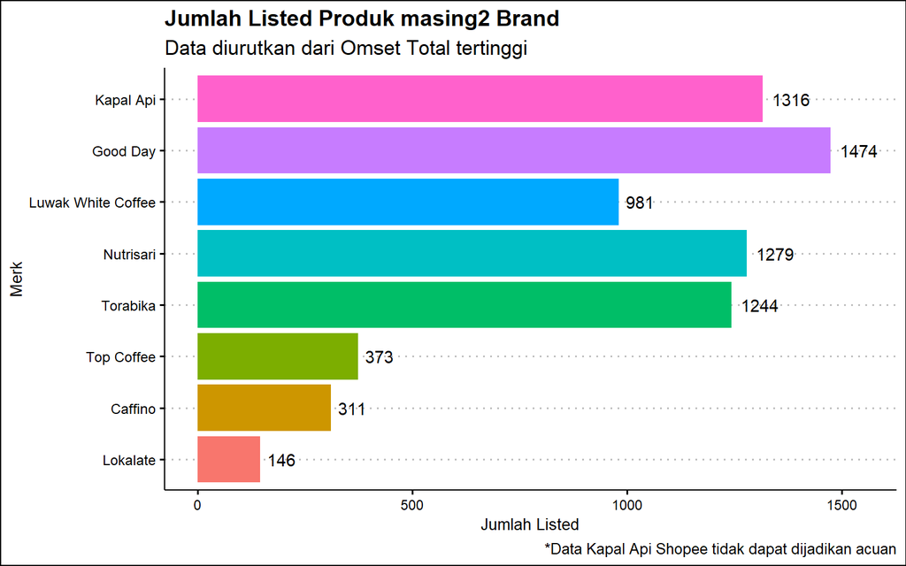

Terdapat **146 Listed Produk Lokalate**, sehingga apabila dihitung, **rata2 Listed / Seller** sebesar **1.37** dengan **Median 1,** artinya setengah seller hanya menjual 1 jenis produk lokalate.

Untuk melihat lebih jelas bagaimana Korelasi dari Omset dengan Jumlah Seller dan Listed Produk, kita dapat menghitungnya dengan Metode *Spearman* (n<30). Hasil dari perhitungannya dapat kita sajikan dalam *Correlation Matrix* sebagai berikut:

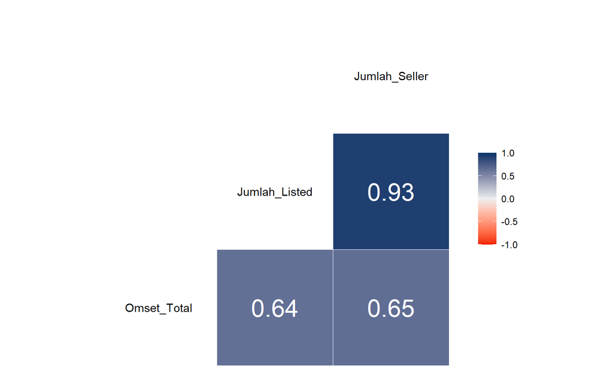

Variabel `Jumlah_Seller` dan `Jumlah_Listed` memiliki **korelasi positif** dan **cukup** **kuat** terhadap `Omset_Total`

Namun, basis data yang digunakan adalah gabungan dari dua marketplace, Tokopedia dan Shopee. Selanjutnya kita akan melihat *Apakah salah satu Marketplace “menjual” Kopi Sachet lebih baik dari Marketplace lainnya?*

# Analisa Marketplace

Dari **Total Omset Kopi Sachet** **tanpa Kapal Api** sebesar **Rp 0.9881** **Miliar,** proporsi tiap Marketplace dari Omset tersebut, adalah sebagai berikut

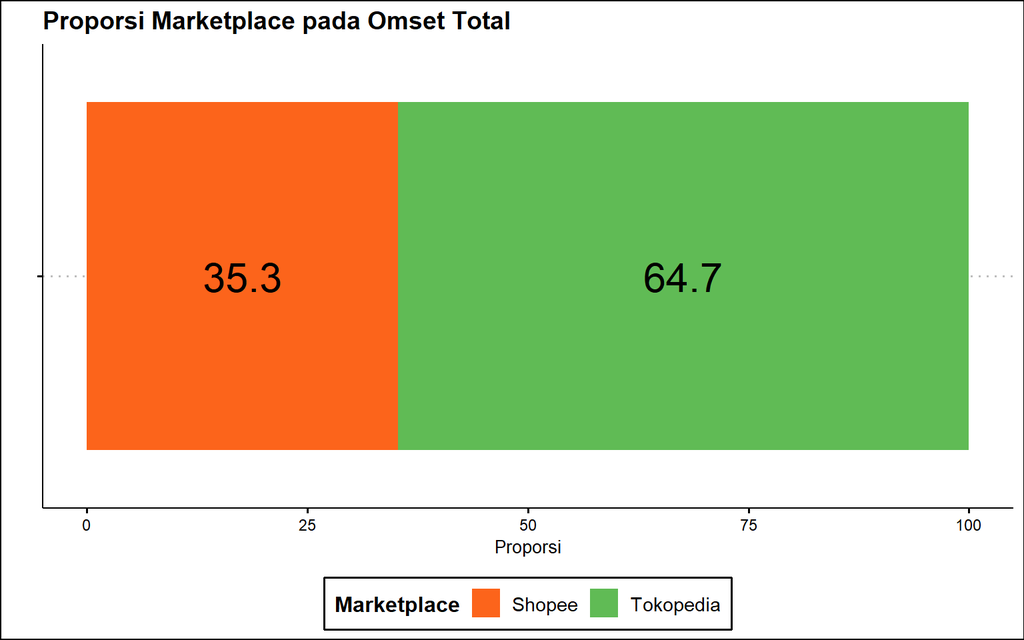

Tokopedia ternyata memiliki **hampir 2x lipat** omset shopee **(diluar Kapal Api)**

Kemudian untuk lebih detailnya, dari tabel dibawah, dapat kita lihat bahwa **Tokopedia** memang memiliki jumlah seller dan jumlah listed produk Kopi Sachet yang **lebih banyak** dari **Shopee.**

|  | Marketplace | Omset_Total | Jumlah_Listed | Jumlah_Seller |
| --- | --- | --- | --- | --- |
| 1 | Shopee | 348.6 | 2055 | 1311 |
| 2 | Tokopedia | 639.5 | 2474 | 1425 |

Namun, apabila kita melihat rata2 dan median dari **Omset/Seller** dan **Omset/Listednya**

|  | Marketplace | Rata2 Omset per Listed Produk | Median Omset per Listed Produk | Rata2 Omset per Seller | Median Omset per Seller |
| --- | --- | --- | --- | --- | --- |
| 1 | Shopee | 169000 | 21740 | 266000 | 20000 |
| 2 | Tokopedia | 258000 | 4300 | 449000 | 0 |

**Tokopedia** memang memiliki **Rata2** **Omset per Seller** dan **Omset per Listed** yang lebih besar dari **Shopee.**

Namun, apabila kita melihat dari **Mediannya,** yang terjadi adalah kebalikannya, dimana **Tokopedia lebih rendah** dari **Shopee.**

> Hal ini mengindikasikan, walaupun Tokopedia memiliki lebih banyak seller dari Shopee, sebagian besar Omsetnya hanya berasal beberapa toko saja, bahkan setengah dari seller di Tokopedia tidak mendapatkan omset sama sekali.

*Apakah fenomena dimana Omset/Seller dan Omset/Listed Kopi Sachet lebih besar di Tokopedia daripada Shopee terjadi di semua Brand? atau ada hanya Brand2 tertentu saja?*

# Analisa Brand Kopi Sachet

Pertama, dari Omset Total Brand yang dapat dilihat sebelumnya, kita akan lihat proporsinya serta Jumlah Seller dan Listed Produk tiap2 Brand di masing2 Marketplace

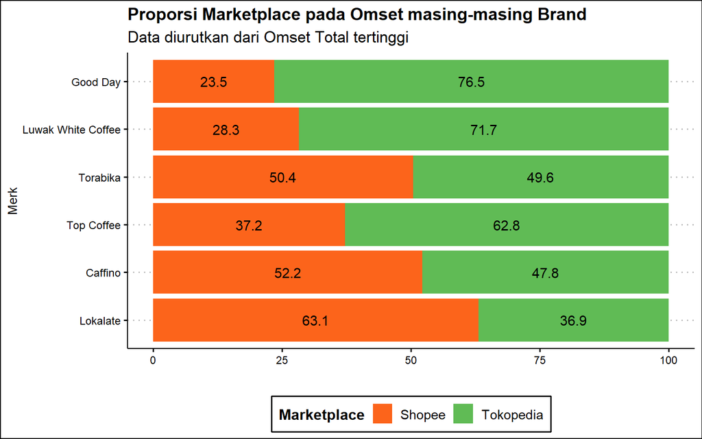

> **Hampir semua brand** memiliki **Omset yang lebih besar** (atau setidaknya hampir sama) **di Tokopedia**. **Hanya Lokalate** saja yang **Omset Tokopedian**ya hanya **36.9%** dari Omset Total

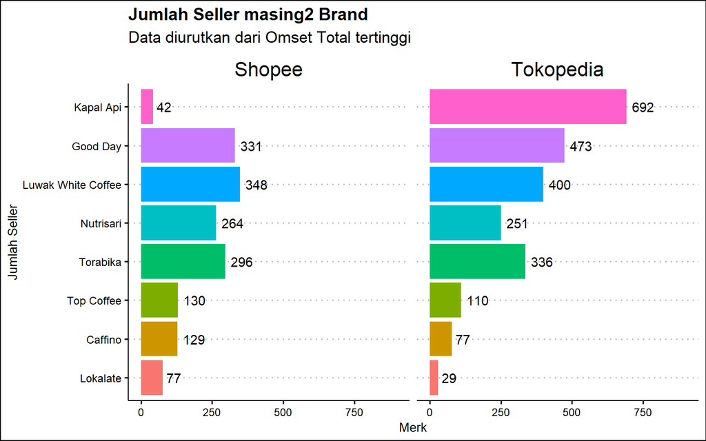

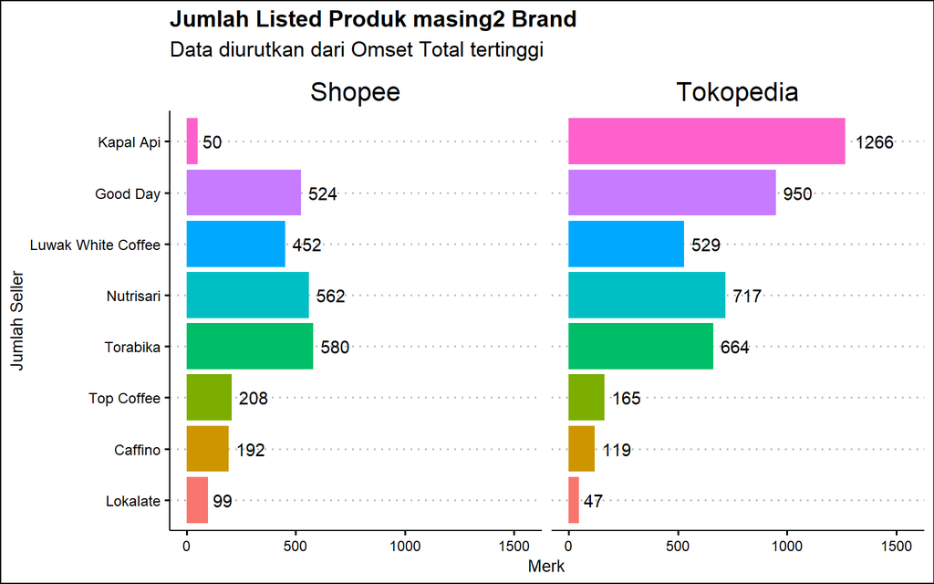

Sama seperti sebelumnya, kita akan melihat rata2 dan median **Omset per Seller** dan **Listed** dari masing2 Brand, (NS dipakai hanya sebagai acuan)

## Omset per Listed masing-masing Brand

Pertama, kita akan melihat *berapa omset rata2 listed produk dari tiap brand dan apakah semua listed produk memiliki omset yang sama*

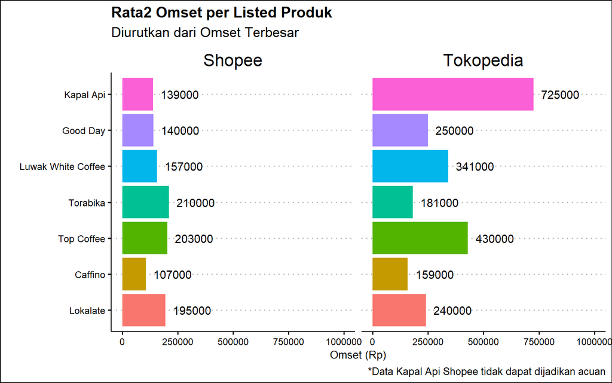

**Lokalate** memiliki **rata2 Omset per Listed Produk terbesar ke 3 di Shopee** dan lebih besar dari Caffino di kedua marketplace

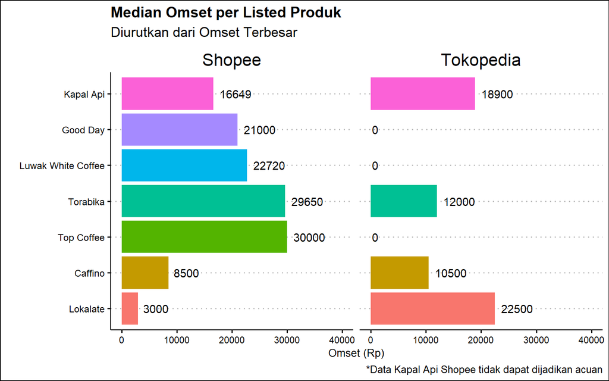

Namun, dengan rata2 omset yang signifikan lebih besar dari median, menandakan omset hanya berasal dari beberapa listed produk saja.

> Grafik Median Omset menandakan setidaknya 50% produk **Lokalate** memiliki omset bulanan sebesar Rp 3.000 di Shopee dan Rp 22.500 di Tokopedia

Selain, Caffino dan Lokalate, semua Brand Kopi Sachet memiliki **median** yang lebih besar di Shopee daripada Tokopedia.

*Sekarang Kalau kita lihat dari segi Sellernya*

## Omset per Seller masing-masing Brand

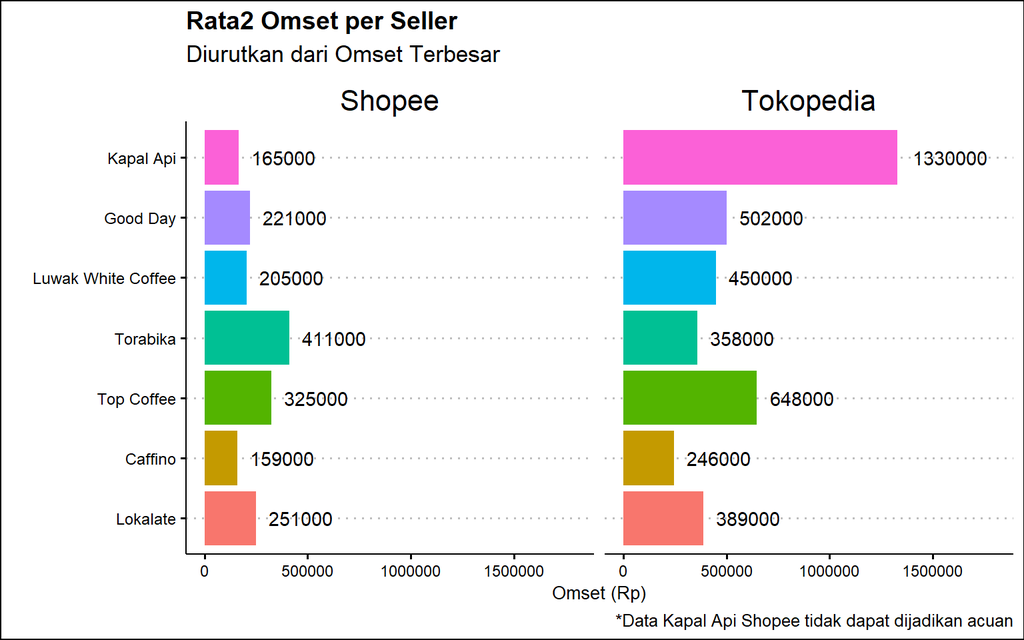

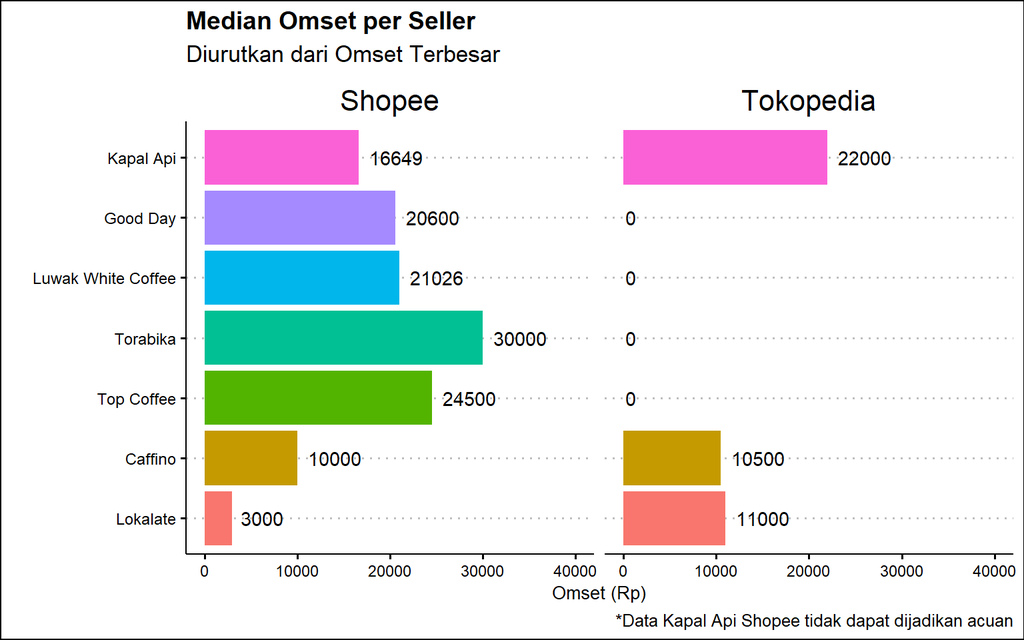

Median 0 menandakan setengah dari Seller tidak memiliki omset sama sekali dalam 1 bulan terakhir.

Sama seperti fenomena sebelumnya, dimana kita dapat melihat **Lokalate** memiliki **Rata2** **Omset per Seller** yang **lebih besar dari Caffino**. Namun, mediannya cenderung sama / lebih rendah (di Shopee).

> Hal ini mengindikasikan, sebagian besar Omset Lokalate hanya berasal beberapa toko saja

Kita selanjutnya akan melihat *Toko / Seller mana saja yang menjual produk dengan “baik”?*

# Analisa Seller

Kita akan menggunakan asumsi bahwa toko / seller yang menjual produk dengan “baik” adalah toko / seller yang memiliki omset > rata-rata omset brandnya di masing2 marketplace.

Berikut adalah **List Toko2 dengan Omset diatas rata-rata Omset per Seller** masing masing Brand tersebut

|  | Marketplace | Merk | seller | Omset per Seller |
| --- | --- | --- | --- | --- |
| 1 | Shopee | Lokalate | nutrimart | 13727100 |
| 2 | Shopee | Lokalate | firianiy | 1208800 |
| 3 | Shopee | Lokalate | jangkung25 | 849000 |
| 4 | Shopee | Lokalate | jangan_lupa_sholat | 590382 |
| 5 | Shopee | Lokalate | susanpermata | 440600 |
| 6 | Shopee | Lokalate | fajarnet89 | 256500 |
| 7 | Shopee | Caffino | warungpintarindonesia | 5320772 |
| 8 | Shopee | Caffino | smart_byshopee | 2508100 |
| 9 | Shopee | Caffino | istanacemilan | 1212955 |
| 10 | Shopee | Caffino | supershop15 | 975000 |

[output cut: 468 more lines]

Serta dalam bentuk Grafis berupa *Wordcloud* dengan ukuran hurufnya sebanding dengan proporsi omset toko di brand tersebut

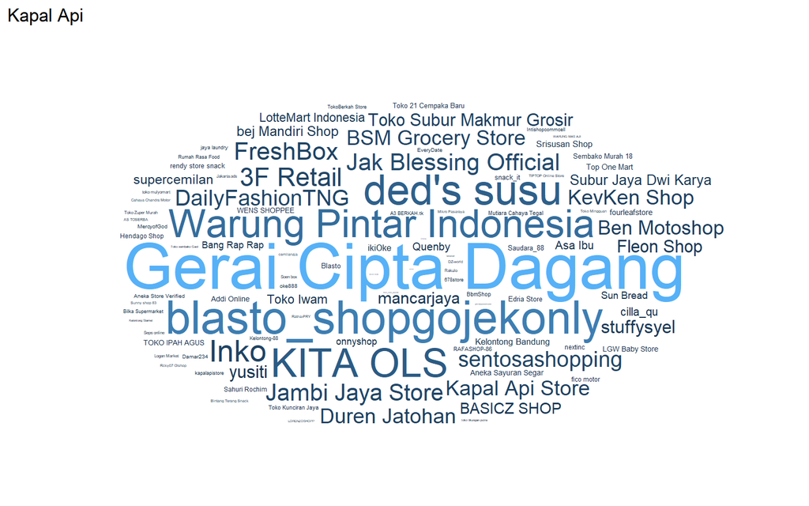

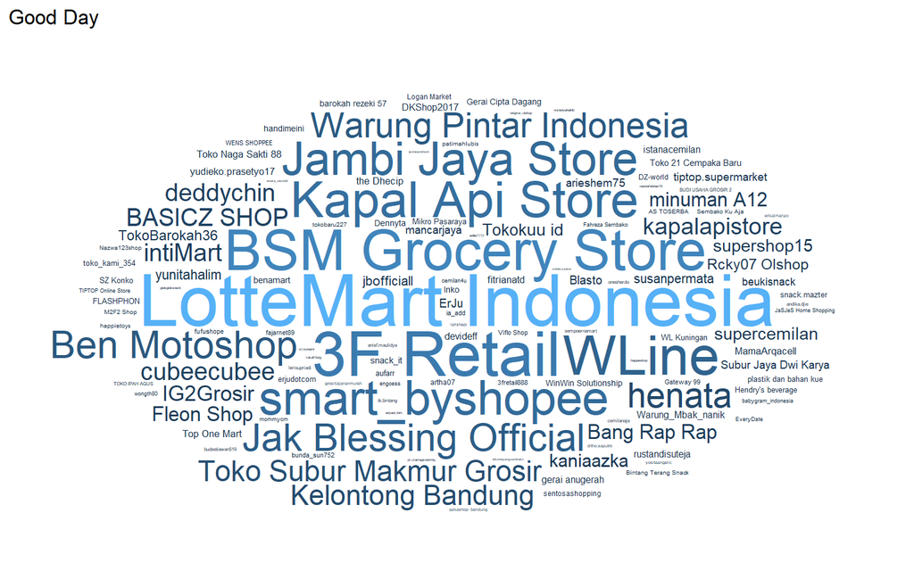

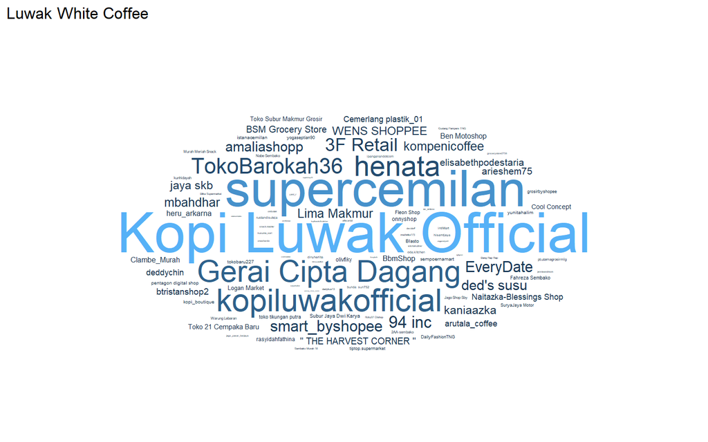

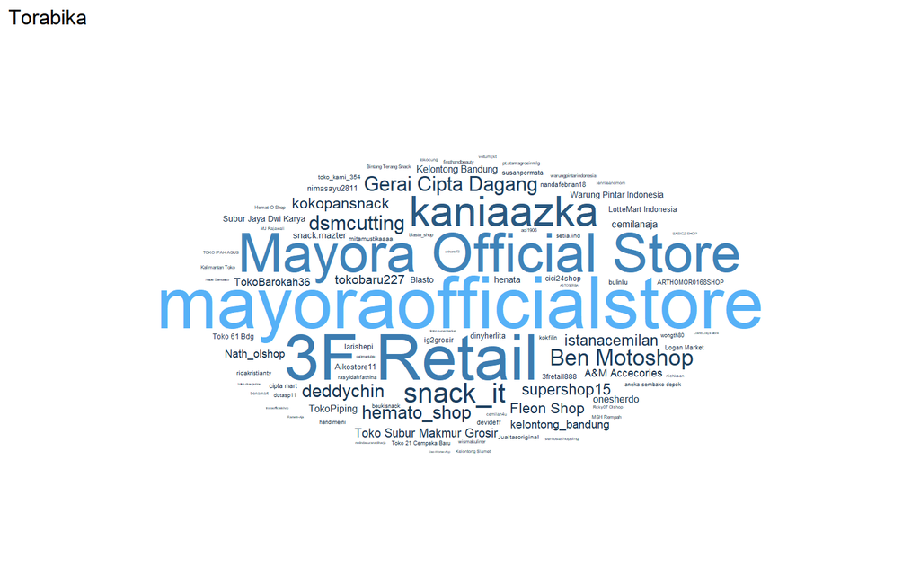

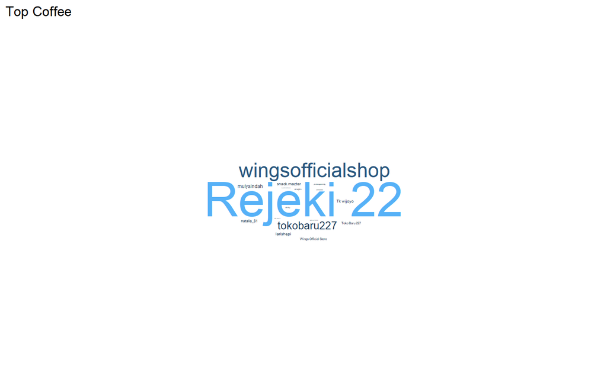

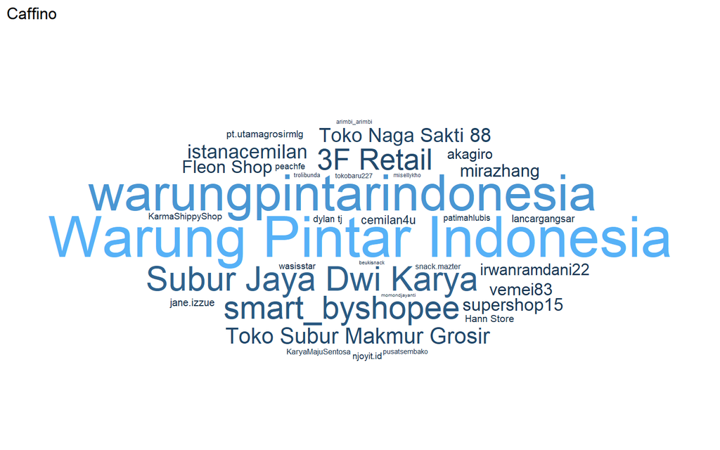

[figure not shown]

Diantara toko / seller tersebut, terlihat ada Official Store masing2 brand seperti Nutrimart, WingsOfficial, Mayora dll

Terdapat pula beberapa seller yang menjual lebih dari satu brand, seperti

1. 3F Retail ([**Tokopedia**](https://www.tokopedia.com/3fretail)/ [**Shopee**](https://shopee.co.id/3fretail888)) yang merupakan Toko kelontong yang menjual makanan bermerek hingga keperluan rumah tangga
2. Gerai Cipta Dagang ([**Tokopedia**](https://www.tokopedia.com/geraicemal)/ [**Shopee**](https://shopee.co.id/geraicemalcemil)) yang juga toko kelontong namun lebih fokus ke makanan dan sembako
3. Warung Pintar Official ([**Tokopedia**](https://www.tokopedia.com/warungpintarco)/ [**Shopee**](https://shopee.co.id/warungpintarindonesia)) yang merupakan “supermarket” official yang dimiliki oleh startup [**Warung Pintar**](https://warungpintar.co.id/)

Berikut adalah list lengkap toko / seller beserta jumlah brand yang dijual di toko tersebut, diurutkan dari Omset_Total Toko (dalam Juta Rupiah) tertinggi

Catatan:

1. Omset per Brand = Omset tiap Brand di Toko / Seller tersebut
2. Omset Toko (All Brand) = Penjumlahan Omset seluruh Brand di Toko / Seller tersebut
3. Jumlah Brand per Seller = Jumlah Brand yang dijual di Toko / Seller tersebut

|  | Marketplace | seller | Brand | Omset per Brand | Omset Toko (All Brand) | Jumlah Brand per Seller |
| --- | --- | --- | --- | --- | --- | --- |
| 1 | Tokopedia | Gerai Cipta Dagang | Kapal Api | 97.1 | 118.59 | 4 |
| 2 | Tokopedia | Gerai Cipta Dagang | Luwak White Coffee | 14.4 | 118.59 | 4 |
| 3 | Tokopedia | Gerai Cipta Dagang | Torabika | 5.97 | 118.59 | 4 |
| 4 | Tokopedia | Gerai Cipta Dagang | Good Day | 1.12 | 118.59 | 4 |
| 5 | Tokopedia | Warung Pintar Indonesia | Kapal Api | 50.7 | 67.97 | 4 |
| 6 | Tokopedia | Warung Pintar Indonesia | Good Day | 9.02 | 67.97 | 4 |
| 7 | Tokopedia | Warung Pintar Indonesia | Caffino | 6.47 | 67.97 | 4 |
| 8 | Tokopedia | Warung Pintar Indonesia | Torabika | 1.78 | 67.97 | 4 |
| 9 | Tokopedia | 3F Retail | Torabika | 22.2 | 65.463 | 6 |
| 10 | Tokopedia | 3F Retail | Kapal Api | 20.7 | 65.463 | 6 |

[output cut: 468 more lines]

Melihat beberapa reseller yang memiliki omset lebih besar dari Official Store Brandnya, berikut adalah listnya

|  | Marketplace | Merk | seller | Omset per Seller |
| --- | --- | --- | --- | --- |
| 1 | Shopee | Good Day | smart_byshopee | 12349100 |
| 2 | Shopee | Good Day | kapalapistore | 4352740 |
| 3 | Tokopedia | Top Coffee | Rejeki 22 | 58000000 |
| 4 | Tokopedia | Top Coffee | mulyaindah | 2352000 |
| 5 | Tokopedia | Top Coffee | Tk wijoyo | 1742000 |
| 6 | Tokopedia | Top Coffee | Wings Official Store | 1601400 |
| 7 | Tokopedia | Good Day | LotteMart Indonesia | 24021000 |
| 8 | Tokopedia | Good Day | BSM Grocery Store | 16704700 |
| 9 | Tokopedia | Good Day | 3F Retail | 14922272 |
| 10 | Tokopedia | Good Day | Kapal Api Store | 13057910 |

[output cut: 14 more lines]

*Kita akan coba bandingan dan lihat proporsi OS dan Reseller dari Omset Totalnya*

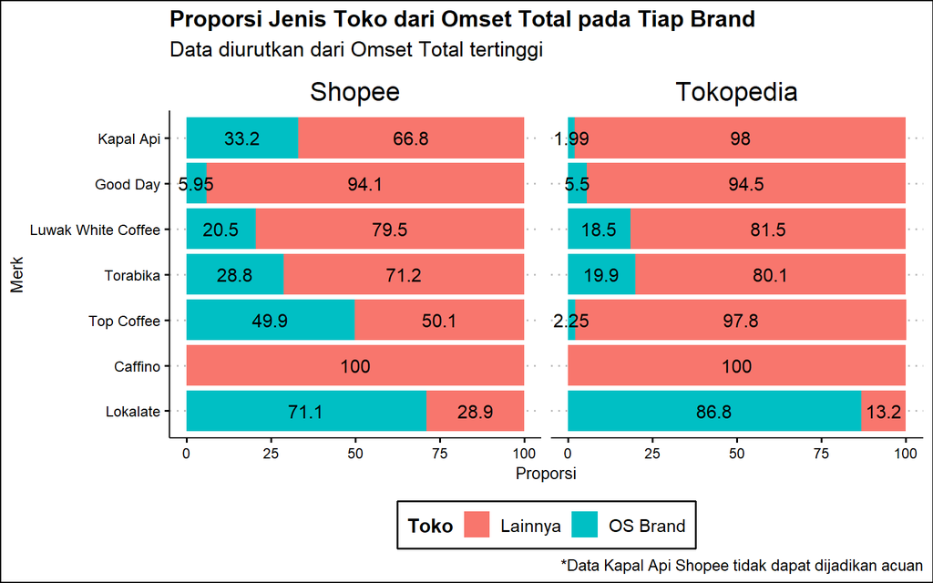

Ternyata, **Hanya Lokalate** saja yang **Omsetnya Mayoritas didapatkan dari Official Store Brandnya**. Untuk Brand Lain, **minimal 50% Omset didapat dari Reseller**.

Setelah membahas dari Sisi Marketplace dan Brand Kopi secara keseluruhan, kita akan melihat lebih lanjut dari sisi jenis kopinya,

*Bagaimana omset dilihat dari Jenis Kopinya? Apa rasa yang paling laku?*

# Analisa Jenis Kopi

Dalam analisa ini, Jenis kopi akan dibagi menjadi 4 Jenis:

1. Kopi Hitam
2. 2 in 1 (Hitam + Gula)
3. 3 in 1 (Hitam + Gula + Krimer) atau Kopi dengan Rasa (Aren, Mocca, Latte dll)
4. Lainnya

Pertama, kita akan melihat total Omset masing2 Jenis Kopi di tiap marketplace

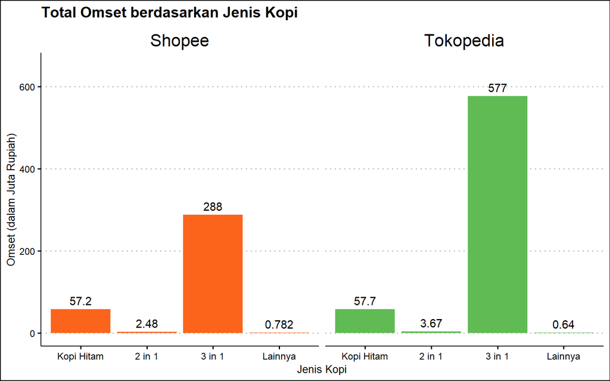

Tanpa termasuk Omset Kapal Api, **Kopi 3 in 1** memiliki **Omset Total** sebesar **Rp 865 Juta**

Dari seluruh Omset tersebut, *Berapa market share tiap Brand? Bagaimana proporsi SKUnya? Apa saja rasa yang paling laku?*

## Analisa Kopi 3 in 1

Pertama, kita akan melihat omset di masing-masing Marketplace, dimana Total Omset Tokopedia melebihi Shopee

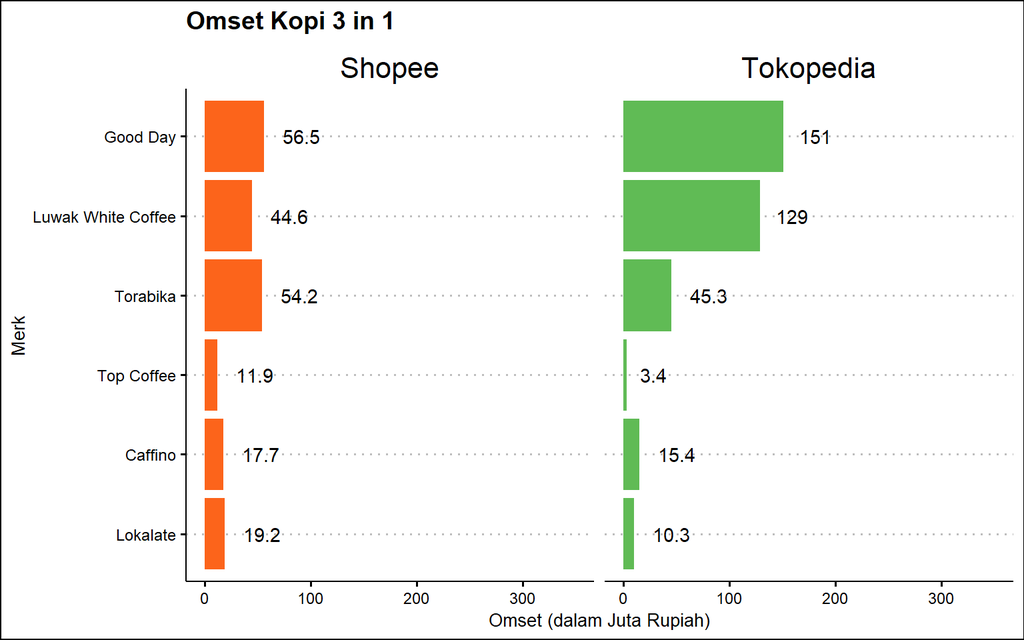

Pada analisis kali ini, SKU dibagi menjadi 5 jenis

1. Satuan
2. 5 Sachet
3. 10 Sachet
4. 40 Sachet
5. Lainnya -> Bentuk lainnya bisa bermacam2, antara lain *pouch refill, 3/*15/20 Sachet dll

Berikut adalah grafik proporsi SKU pada Omset 3 in 1 pada masing-masing Brand

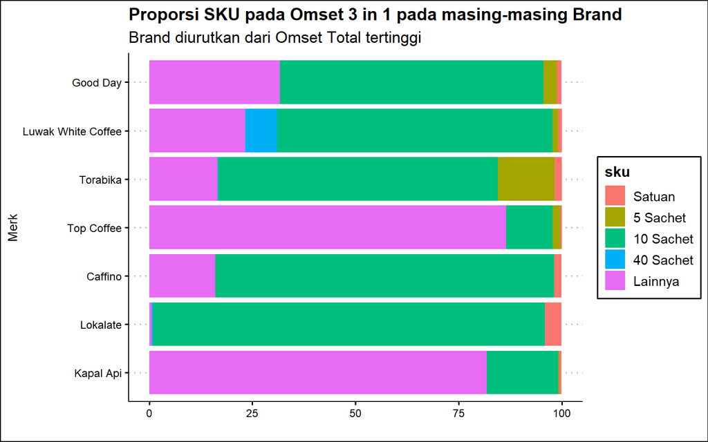

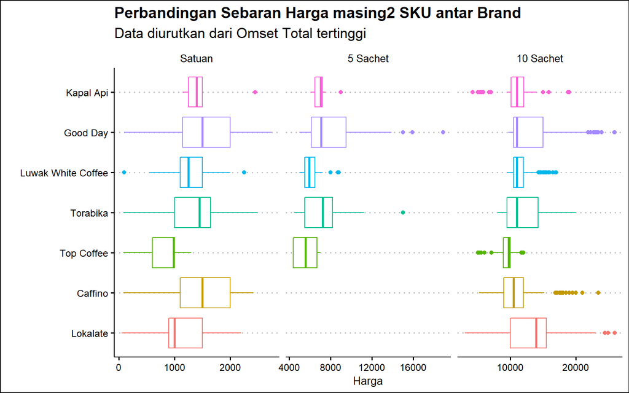

Untuk SKU 10 Sachet, Lokalate adalah merk dengan median harga yang paling tinggi hampir mencapai Rp 15rb per renceng, sementara merk2 lainnya hanya berkisar Rp 10 rb per renceng.

Lalu *bagaimana dengan rasa dari 3 in 1 ?*

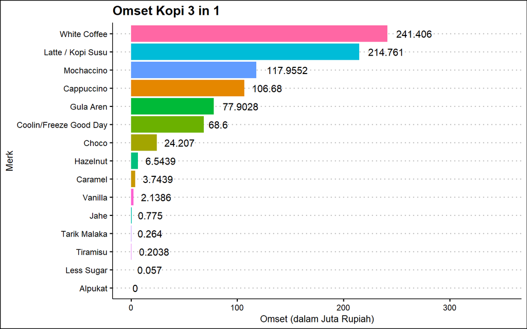

> Top 5 Rasa 3 in 1 adalah **Rasa White Coffee, Latte / Kopi Susu, Mochaccino, Cappucino, dan Gula Aren**

*Siapa saja yang menjual Gula Aren? Bagaimana Omsetnya?*

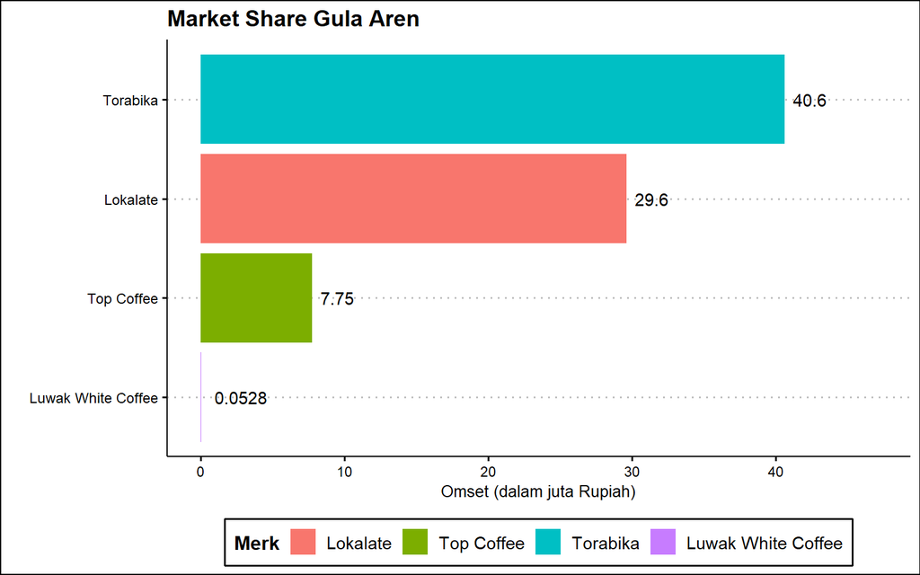

Ternyata ada 4 Brand, dengan Lokalate berada di peringkat 2 *market share gula aren* dengan omset sebesar Rp 29.6 Juta

Apabila kita lihat Marketshare di Tiap2 Marketplace

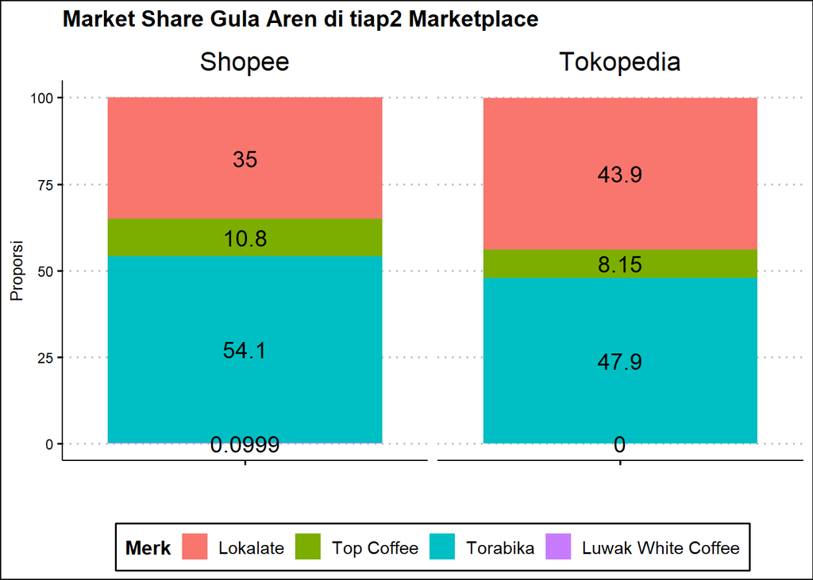

Torabika mempunyai *marketshare* sekitar 50% di tiap2 Marketplace, diikuti **Lokalate sebesar 35% di Shopee dan 43.9% di Tokopedia**

*Bagaimana sebaran harga kopi gula aren?*

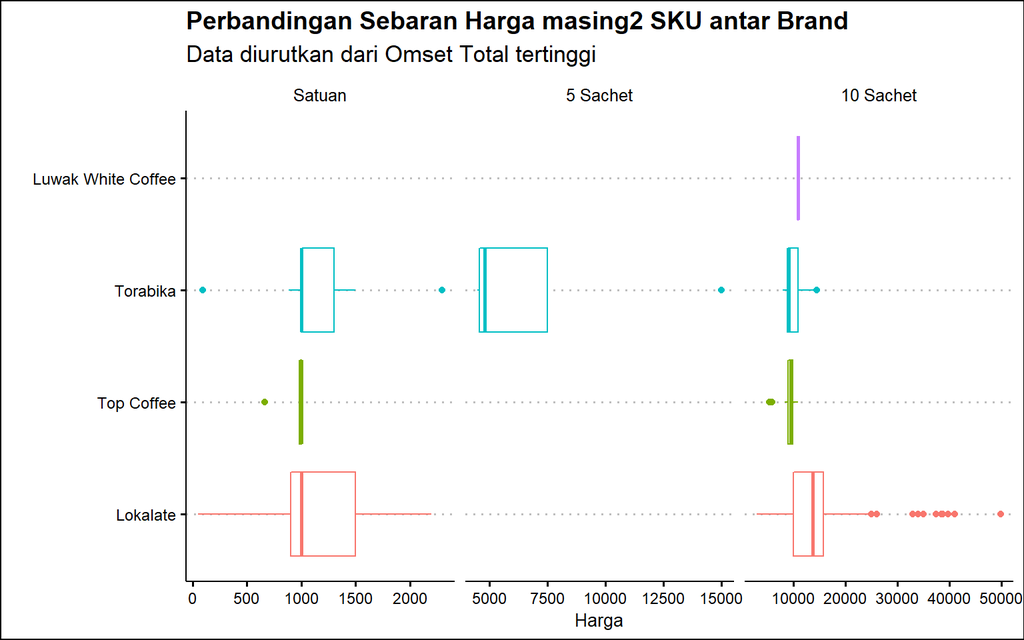

Ternyata hampir sama seperti sebelumnya, **Harga Lokalate untuk Ukuran 10 Sachet paling tinggi diantara Brand2 lainnya**

# Analisis Lanjutan

## Omset Retail

Di Shopee, terdapat toko retail bernama “smart_byshopee” yang merupakan Toko yang penjualannya dikelola oleh Shopee sendiri.

Kita ingin melihat *Bagaimana omset toko retail tersebut dibandingkan dengan Official Store dan Reseller lainnya?*

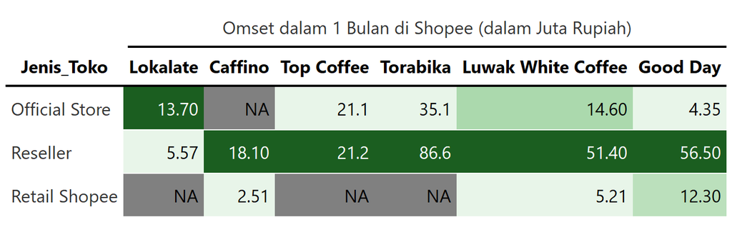

Terdapat 3 Brand Kopi Sachet yang dijual oleh “smart_byshopee” yaitu Caffino, Luwak White Coffee, dan Goodday

Hanya Good Day saja yang Omset Retailnya melebihi Official Store (Hampir 3x lipatnya) sebesar 12juta rupiah

Sedangkan untuk brand lainnya, Omset Retailnya hanya sekitar 10% dari Omset Reseller

## Omset Retail SKU

Setelah dicek lebih lanjut, ternyata Toko2 Retail umumnya menjual ukuran SKU yang berbeda, umumnya ukuran2 besar seperti pouch, bag, 30 sachet, atau bundle2 lainnya

Kita akan cek apakah ada perbedaan omset antar jenis toko bila dilihat dari SKUnya

|  | Omset dalam 1 Bulan di Shopee (dalam Juta Rupiah) Satuan | Omset dalam 1 Bulan di Shopee (dalam Juta Rupiah) 5 Sachet | Omset dalam 1 Bulan di Shopee (dalam Juta Rupiah) 10 Sachet | Omset dalam 1 Bulan di Shopee (dalam Juta Rupiah) 40 Sachet | Omset dalam 1 Bulan di Shopee (dalam Juta Rupiah) Lainnya |
| --- | --- | --- | --- | --- | --- |
| Lokalate |  |  |  |  |  |
| Reseller | 0.96 | - | 4.50 | 0.11 | 0.00 |
| Official Store | - | - | 13.70 | - | - |
| Caffino |  |  |  |  |  |
| Reseller | 0.62 | - | 17.10 | - | 0.33 |
| Retail Shopee | - | - | - | - | 2.51 |
| Top Coffee |  |  |  |  |  |
| Reseller | 0.35 | 0.00 | 2.88 | - | 17.90 |
| Official Store | - | 2.15 | 6.52 | - | 12.40 |
| Torabika |  |  |  |  |  |
| Reseller | 1.78 | 1.30 | 80.40 | 0.18 | 2.90 |
| Official Store | - | 0.88 | 30.00 | - | 4.21 |
| Nutrisari |  |  |  |  |  |
| Reseller | 5.53 | 0.03 | 83.80 | 0.72 | 0.59 |
| Official Store | - | - | 23.40 | - | 5.09 |
| Luwak White Coffee |  |  |  |  |  |
| Reseller | 0.90 | 1.14 | 37.10 | - | 12.30 |
| Official Store | - | 0.28 | 2.05 | 0.98 | 11.30 |
| Retail Shopee | - | 1.38 | 1.78 | - | 2.05 |
| Good Day |  |  |  |  |  |
| Reseller | 2.15 | 1.63 | 44.60 | - | 8.07 |
| Official Store | - | 0.27 | 2.45 | - | 1.64 |
| Retail Shopee | - | 4.83 | 3.72 | - | 3.80 |

Hal yang menarik adalah,

Walaupun Omset SKU 10 Sachet di Reseller jauh melebihi Toko lainnya,

Omset 5 Sachet dan Ukuran “Lainnya” di OS atau Retail cenderung lebih tinggi atau tidak berbeda jauh dengan Reseller